# Performance-Related Biases and Perceptions

Daniel Bonfil

2023-09-21

# Chapter 1

## Title

End Bias in Retrospective Voting: The Role of Framing and Affective Judgments

## Abstract

The evaluation of presidential economic performance plays a controversial role in retrospective voting and democratic accountability. Retrospective voting involves citizens assessing the past economic performance of incumbents when making electoral decisions, while democratic accountability ensures that elected representatives remain responsive to the needs of their constituents. However, the tendency for voters to simplify retrospective assessments by substituting conditions at the end for the whole, known as the end bias, can distort their judgments. We study the influence of framing, or the selection and presentation of information, on mitigating the end bias and enabling more informed assessments of the incumbent’s economic performance. Drawing on a series of surveys and experiments, we demonstrate how voters unintentionally rely on election-year performance due to the accessibility of this information, despite their actual intention to judge presidents evenly throughout the term. The findings suggest that providing voters with both yearly and cumulative economic framing can align their actions with their intentions, eliminating the election-year emphasis. Moreover, we explore the influence of pre-existing affective judgments, which refer to the emotional ties and sentiments individuals hold toward political leaders, on overcoming the end bias, particularly in the evaluation of identified incumbents.

## Introduction

In the realm of retrospective voting and democratic accountability, evaluating the economic performance of incumbents holds a controverted importance. A noteworthy challenge arises from voters’ tendency to prioritize short-term economic conditions shortly before elections, rather than considering the overall performance throughout an incumbent’s term (Achen & Bartels, 2004b). This behavior raises three critical issues: firstly, it leads politicians to focus on short-term growth at the expense of long-term planning; secondly, it can overshadow sustained economic strategies with short-term manipulations; and thirdly, it fosters myopic policies within each presidential economic juncture rather than evaluating incumbents’ preparedness (Bartels, 2008; A. Healy & Lenz, 2014; Tufte, 1978). Additionally, research conducted by Sarafidis (2007) underscores the prevalence of voters’ memory constraints, limiting their ability to retain and process information, while Campello & Zucco (2022) further emphasize the issue of misattribution of responsibility, which occurs when voters attribute economic conditions to incumbents even when those conditions are determined by factors beyond governmental control, influencing their evaluation of incumbents’ economic performance.

The end bias, a cognitive tendency to substitute the end for the whole, plays a significant role in voters’ evaluations of economic performance. The concept of “Attribute Substitution”, illustrated by Kahneman (2003) and Kahneman & Frederick (2002), reveals how individuals unconsciously replace a target attribute with a more readily accessible, related attribute when making judgments. This phenomenon, exemplified in experiments by Kahneman et al. (1993) involving the immersion of hands in cold water, showcases people’s inclination to remember experiences based on peak and end conditions, termed the “Peak-End Rule.” This bias extends to diverse retrospective evaluations ranging from vacations to colonoscopies that exhibit the general tendency for people to substitute overall assessments with easily accessible peak and end information (e.g., Loewenstein & Prelec (1993); Baumgartner et al. (1997); Ross & Simonson (1991); Zauberman et al. (2006)).

Previous political science research posited “citizens’ limited memory” and the perception that “election-year economy is particularly informative” as contributors to this bias (MacKuen et al., 1992; Sarafidis, 2007). However, A. Healy & Lenz (2014) propose an intriguing explanation known as the “end heuristic” drawing from psychological research by Liersch & McKenzie (2009) and Varey & Kahneman (1992), which shows that individuals overweight discomfort at the end when evaluating hypothetical sequences of unpleasant episodes. Contrary to prevailing explanations, the end-heuristic suggests that voters indeed intend to judge presidents based on cumulative growth but due to the accessibility of election-year performance information, voters inadvertently substitute it for cumulative growth.

The concepts of retrospective voting and democratic accountability are closely intertwined with framing, as political actors and media outlets often frame issues to influence public opinion and perception of government performance (McCombs & Shaw, 1972). Scholars like Goffman (1986) and Lakoff (2014) argue that the way an issue or message is framed can activate certain cognitive schemas and influence how individuals understand and respond to it. To reinforce democratic accountability, the adoption of yearly and cumulative economic framing could effectively mitigate the end bias. As implied in the research conducted by Liersch & McKenzie (2009) and demonstrated by A. Healy & Lenz (2014), providing voters with information that promotes the alignment of voters’ actions with their intentions holds the potential to eliminate the election-year emphasis and foster more balanced and informed assessments of incumbents’ economic performance.

In addition to framing economic information, it is crucial to understand the influence of pre-existing affective judgments in evaluating identified incumbents. We explore the influence of emotional ties and sentiments on overcoming the end bias, particularly in the evaluation of identified incumbents. Emotions and irrelevant events, unrelated to economic conditions, can still play a significant role in voters’ decisions as shown by Malhotra et al. (2009) with the effects of wins and losses of college basketball games on presidential approval, or natural disasters like floods and tornadoes in presidential reelection by A. Healy & Malhotra (2010). Similarly, Campello & Zucco (2022) extend this literature by testing whether individuals’ prior affective ties to political leaders cloud their capacity to discount exogenous conditions and hinder the objective evaluation of available information.

Furthermore, the end heuristic can interact with affective judgments, as individuals’ emotional reactions to distinct events may influence their evaluations of economic performance. Lerner et al. (2004) study the interplay between emotions and judgment highlighting the potential impact of affective responses on economic evaluations, while Malhotra & Margalit (2014) examine to what extent is retrospection affected by the expectations that leaders set in advance. The interplay between affective judgments and cognitive biases accentuates the significance of comprehending how emotional responses can shape perceptions of economic conditions, thus influencing voting behavior. Consequently, this scholarship delves into whether framing economic information with both yearly and cumulative levels can act as a mitigating factor, counteracting the influence of affective judgments and facilitating a more balanced and informed assessment of the economic performance of identified incumbents.

## Theoretical Background

Retrospective voting, an essential tenet of democratic accountability, involves voters assessing incumbents’ past economic performance during elections. Citizens inherently tend to reward leaders during prosperous periods and hold them accountable in times of economic challenges. Scholarship by Fiorina (1981) and Bartels (2008) emphasize its significance, aligning electoral choices with economic realities and attributing leaders with responsibility for their policy decisions. However, this seemingly straightforward link is nuanced by framing dynamics and cognitive biases like the end heuristic, as well as their interplay with affective judgements.

Democratic accountability, the bedrock of democratic governance, ensures that elected representatives remain responsive to the needs of their constituents. Noteworthy scholars such as Dahl (1971), Przeworski (1991), and Stokes (2005) have extensively explored the mechanics of accountability, emphasizing the importance of citizen engagement, participation, and the role of institutional design. Additionally, insights from Ostrom (1990) exploration of collective action institutions and Pateman (1970) work on participation in democratic theory illuminate the multifaceted nature of accountability. These theories seamlessly converge with framing dynamics, cognitive biases, and affective judgements, influencing how citizens perceive their representatives and how they hold them accountable. Renowned scholars like Marcus et al. (2000) and Sniderman & Theriault (2004) delve into how framing shapes public opinion and behavior. Furthermore, the interplay between affective judgments and the end heuristic adds complexity to economic evaluations, as emotions play a role in shaping citizens’ perceptions of economic conditions (Malhotra & Margalit, 2014). This intricate interplay, interwoven into the fabric of democratic accountability, underscores the multifaceted nature of voter decision-making.

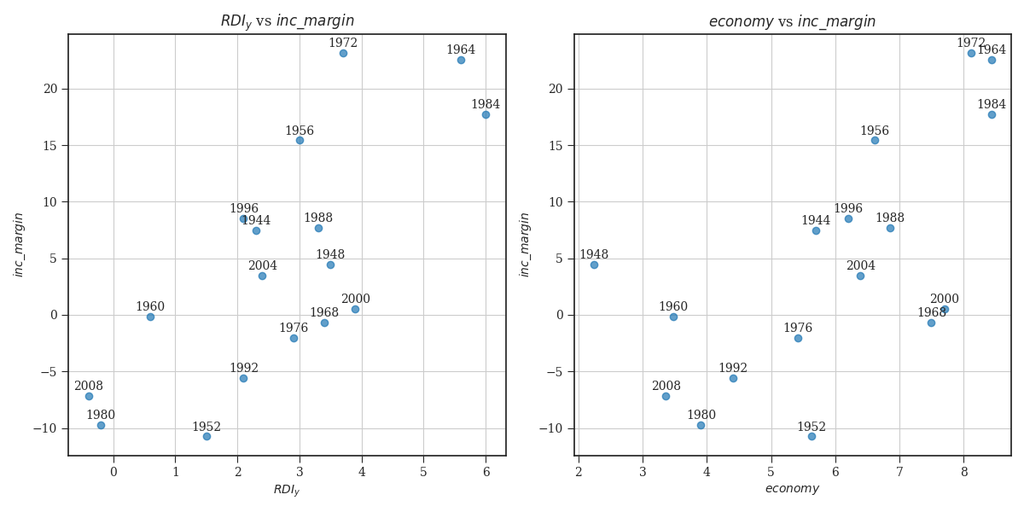

**Figure 1**

The acknowledgment of biases emphasizes the need for a nuanced approach to understanding voter behavior, while recognizing the implications of these biases becomes pivotal for amplifying the informed nature of voters’ decisions and promoting balance and accuracy in retrospective voting. Furthermore, the susceptibility to unrelated events like shark attacks or “Acts of God” (Achen & Bartels, 2004a), suggests that voters might struggle to discern an incumbent’s actions from external causes. Experimental evidence by Huber et al. (2012) further highlights the limitations in voters’ ability to use a retrospective decision rule, even in controlled experimental games, participants tend to overweight recent incumbent performance and are influenced by unrelated events, such as lotteries affecting their welfare. This in turn, suggests that voters’ ability to accurately assess incumbent performance may be subject to biases, and that they may struggle to disentangle the impacts of exogenous factors from the incumbent’s actions.

Exogenous events introduce a layer of complexity into retrospective voting, challenging the notion that economic assessments solely pivot on macroeconomic indicators. While the propensity to reward incumbents during economic booms and punish them during downturns holds, researchers like A. Healy & Malhotra (2010) delve into how exogenous events, such as the effects of wins and losses of college basketball games on presidential approval, or natural disasters like floods and tornadoes on presidential reelection by A. J. Healy et al. (2010) can magnify the impact of economic shocks just before elections. For example, the aftermath of natural disasters offers a clear snapshot of how voters respond to unforeseen economic challenges and acknowledges the interplay between broader contextual factors and voters’ decision-making (Bechtel & Hainmueller, 2011).

The influence of exogenous economic factors, such as commodity prices and international interest rates on presidential success, are central to the findings of Campello & Zucco (2016) and Campello & Zucco (2020b). They explain how voters in Latin American countries are quick to reward incumbent leaders during periods of favorable external economic conditions and penalize them when these conditions are adverse. This responsiveness to external economic fluctuations presents a challenge to the effectiveness of retrospective voting as a mechanism for holding leaders accountable, as voters may not always recognize situations where economic performance is largely determined by factors beyond governmental control.

Similarly, the complex dynamics of economic perceptions and political accountability in developing democracies, particularly focusing on Latin American countries, have been explored by Campello & Zucco (2022). Their research sheds light on a recurring phenomenon described by Duch & Stevenson (2008) wherein voters tend to attribute economic performance, whether positive or negative, to incumbent leaders rather than recognizing the influence of external economic conditions. This misattribution, the authors argue, is not solely a matter of information deficiency; their studies reveal that voters often struggle to accurately apply information, especially when it clashes with their emotional judgments of political figures.

Furthermore, the role played by affective judgments – the emotional ties and sentiments individuals hold toward political leaders is explored by Campello & Zucco (2020a). They find that even when provided with information about exogenous economic shocks, voters often fail to adjust their assessments due to pre-existing emotional connections to leaders. This presents a significant obstacle to rectifying the misattribution of responsibility on economic evaluations as noted by Lodge & Taber (2007). Their studies underscore that addressing this challenge requires more than providing information; it requires understanding the intricate interplay between cognitive processes, emotional judgments, and the broader economic context. Ultimately, the research highlights the complexities involved in fostering effective democratic accountability in developing nations, where economic perceptions can be heavily influenced by factors beyond immediate governmental control.

Framing, coupled with cognitive biases plays a pivotal role in shaping citizens’ responses to economic information. The nexus between democratic accountability and framing dynamics holds significance as political actors and media outlets strategically frame issues to shape public opinion and perceptions of government performance (McCombs & Shaw, 1972). Lakoff (2014) and Goffman (1986) exploration of framing’s impact on public discourse and agenda-setting further emphasize its depth. This dynamic is further complicated by the interaction between framing and affective judgments, which underscores the emotional resonance of political messages as noted by Marcus et al. (2000); Sniderman & Theriault (2004) and the need to deepen our understanding of how citizens perceive their elected representatives and how they hold them accountable.

In the upcoming sections, we offer a comprehensive overview of our research, building upon the previously presented foundational insights. We explore the effects of framing, cognitive biases, and emotional judgments on retrospective voting, with the aim of contributing to the existing literature and enhancing our understanding of this complex democratic process.

## Data and Experimental Design

Our study builds upon the original experiment conducted by A. Healy & Lenz (2014), which aimed to explore the impact of framing yearly and cumulative RDI growth rates on participants’ economic evaluations while addressing the end bias. However, we replicate and extend this experiment using real economic data instead of hypothetical scenarios, specifically utilizing data from 17 US presidential tenures instead of the 25 hypothetical 4-year economies.

To delve into the effects of framing economic information with both yearly and cumulative levels on mitigating the influence of affective judgments, we employed a dataset spanning 17 economies from 1940 to 2008. This dataset includes Real Disposable Income ($RDI$) with both yearly and cumulative growth rates and includes the names of the respective presidents during their terms. This aspect of presidential identification aligns with the approach advocated by Campello & Zucco (2022), enabling us to examine whether framing can indeed facilitate a more balanced and informed assessment of the economic performance of identified incumbents.

The experimental design, as illustrated in Figure 2, was implemented using Qualtrics, and participants were recruited from Amazon Mechanical Turk (MTurk), drawing from a pool of US citizens. Participants were incentivized with a payment of $0.25 US Dollars for their involvement in the study. The survey commenced with a series of feeling thermometers gauging respondents’ sentiments toward political leaders, their ideological preferences, and party identification. Subsequently, participants underwent an attention screener before engaging in economic evaluations across the different conditions. The survey concluded with a brief demographic questionnaire, although we report results without considering these controls.

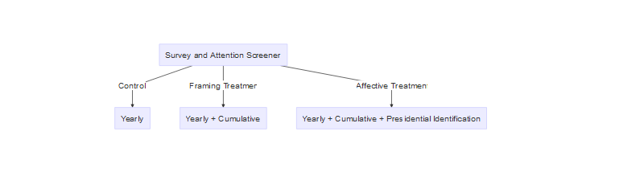

Participants in our study were assigned to one of three distinct conditions. In the Control Condition, participants were presented with yearly growth plots, resembling those depicted in Figure 3. Framing Treatment Condition exposed participants to both yearly and cumulative growth plots presented together, as shown in Figure 4. The Affective Treatment Condition featured the same economic data as the Framing Condition but included the names of the incumbent presidents in the graphs, as depicted in Figure 5. These conditions allowed us to investigate the influence of different framing techniques and the impact of presidential identification on participants’ economic evaluations.

#### Experimental Conditions

- Control Condition:

Participants will be presented with yearly growth plots, resembling those depicted in Figure 3.

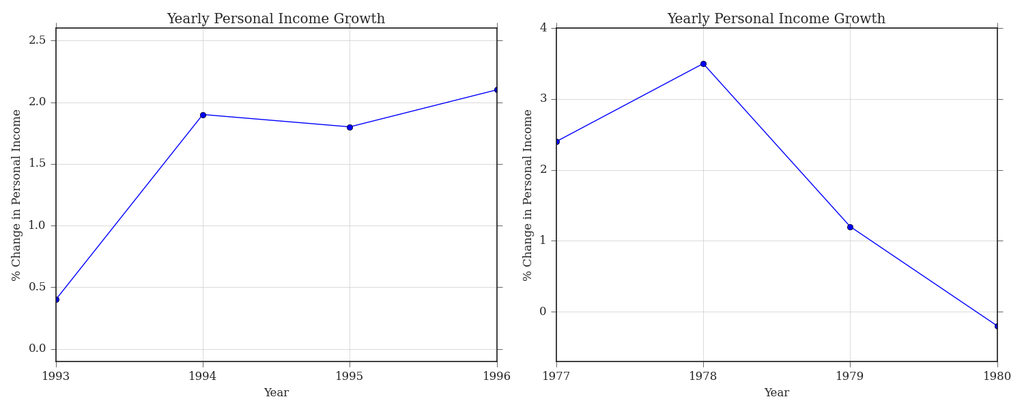

**Figure 3**

The two plots in Figure 3 illustrate the Real Disposable Income (RDI) yearly growth rate, as originally presented by A. Healy & Lenz (2014) and sourced from the Bureau of Economic Affairs (BEA). They show that, even when presented with data from all years of a President’s Term in a simple format, most participants placed substantially more weight on the economy in the final year of presidents’ terms.

For instance, consider the left panel, which corresponds to Bill Clinton’s initial term. It portrays a period of moderate average growth, culminating in a notably strong phase. In contrast, the right panel showcases Jimmy Carter’s sole term, characterized by more robust growth during the first two years, followed by a marked deceleration in the election year. Interestingly, despite the cumulative income growth being superior during Carter’s tenure (6.9% compared to Clinton’s 6.2%), participants consistently evaluated the economy more favorably during Clinton’s first term.

This striking phenomenon underscores the prevalence of the end bias and its potential to influence participants’ economic evaluations, even when presented with comprehensive data from all years of a presidential term.

- Framing Treatment Condition

Participants in this condition will be exposed to both yearly and cumulative growth plots presented together, as shown in Figure 4.

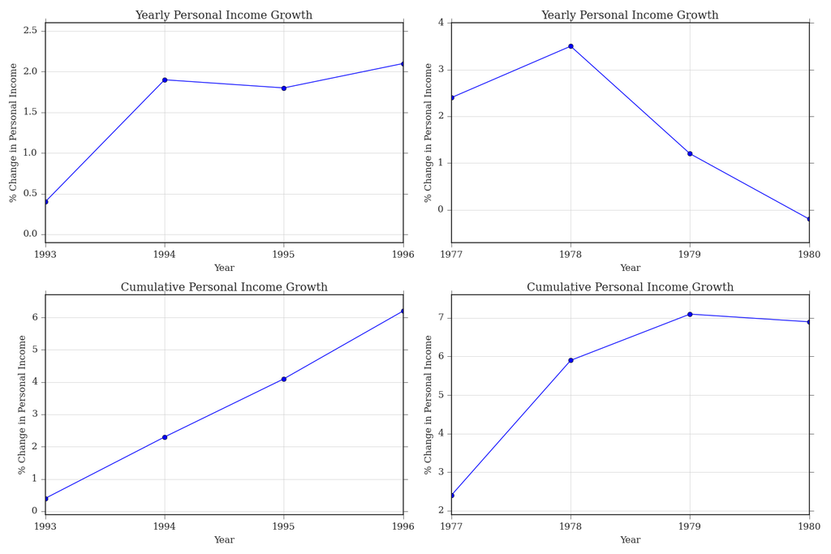

**Figure 4**

- Affective Treatment Condition

Participants in this condition will be presented with the same economic data as in the framing treatment condition. However, the graphs will include the names of the incumbent presidents, as depicted in Figure 5.

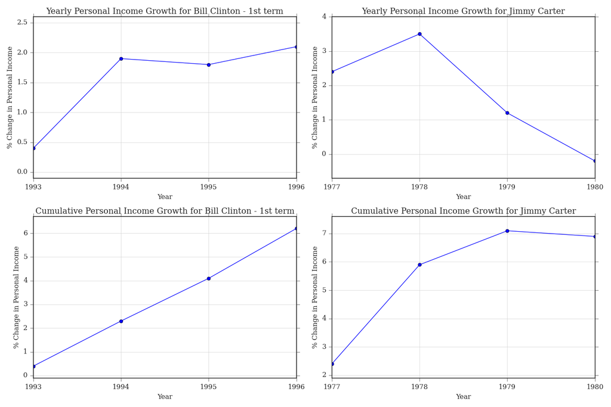

**Figure 5**

### Regression Analysis

To understand the influence of each year on participants’ economic evaluations, we will employ regression analysis. Specifically, we will regress participants’ average economic evaluations on the percentage change in income growth for each of the four years within a presidential term. This regression model is represented by Equation 1:

$$y_i = \beta_0 + \beta_1 X_1 + \beta_2 X_2 + \beta_3 X_3 + \beta_4 X_4 +
\varepsilon_i$$

Where: $y_i$ represents the economic evaluations ($economy$) of participant $i$. $X_1, X_2, X_3,$ and $X_4$ represent the RDI growth rates ($RDI_y$) for the four years of the presidential term. $\beta_1, \beta_2, \beta_3,$ and $\beta_4$ are coefficients estimating the implicit weight assigned to each year. $\varepsilon_i$ represents the error term.

This regression analysis will be applied to all three experimental conditions to compare the influence of framing on participants’ evaluations. By replicating and extending the original experiment with real data and introducing these experimental conditions, we aim to shed light on the complex interplay between framing, cognitive biases, affective judgments, and retrospective voting.

## Hypotheses and Expected Results

### Expected Results

Figure 6 displays the combinations of economic evaluations ($economy$) and Cumulative Real Disposable Income ($RDI_c$) in a cross-sectional manner. It’s evident that the treatment has a positive (negative) impact on evaluations, particularly at both ends of the ($RDI_c$) continuum. Additionally, for combinations characterized by less extreme cumulative growth values, we anticipate a milder yet discernible effect. For a chronological perspective on this phenomenon, please refer to Figure 7, which displays cumulative growth trends alongside economic evaluations for both control and treatment conditions.

We expect the affective treatment to hold statistical significance for values around the framing treatment. This outcome could provide compelling evidence that the findings pertaining to yearly and cumulative framing remain robust even when participants can directly associate cumulative economic performance with a president, effectively mitigating the end-bias and the influence of prior affective judgments.

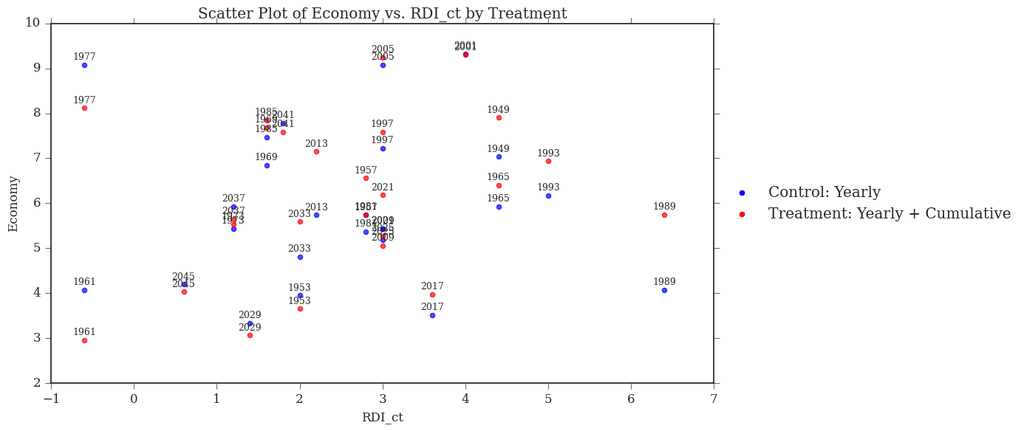

**Figure 6**

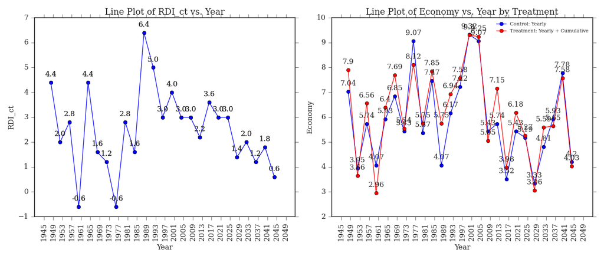

**Figure 7**

## Discussion and Conclusion

The implications of our study extend beyond the realm of economic evaluations during elections. We argue that this and other cognitive biases and perceptions may have broader repercussions, affecting various domains of incumbent performance assessment. The end heuristic’s influence could extend to evaluations of politicians’ effectiveness in areas beyond the economy, thereby posing a more general challenge to democratic accountability. However, our results also provide hope, as they suggest that relatively simple modifications in the information context, such as emphasizing cumulative growth, may empower voters to make more informed and balanced assessments of identified incumbents. While implementing these changes in real-world settings poses challenges, acknowledging the cognitive underpinnings of this phenomenon opens the door to potential solutions that could enhance the functioning of democratic systems and reduce the undue influence of election-year economic fluctuations and affective judgments on electoral outcomes.

# Chapter 2

# Chapter 3

Achen, C. H., & Bartels, L. M. (2004a). *Electoral Responses to Drought, Flu, and Shark Attacks*.

Achen, C. H., & Bartels, L. M. (2004b). *Musical Chairs: Pocketbook Voting and the Limits of Democratic Accountability*.

Bartels, L. M. (2008). *Unequal democracy: The political economy of the new Gilded Age* (Second edition). Russell Sage Foundation.

Baumgartner, H., Sujan, M., & Padgett, D. (1997). Patterns of Affective Reactions to Advertisements: The Integration of Moment-to-Moment Responses into Overall Judgments. *Journal of Marketing Research*, *Vol. XXXIV*.

Bechtel, M. M., & Hainmueller, J. (2011). How Lasting Is Voter Gratitude? An Analysis of the Short- and Long-Term Electoral Returns to Beneficial Policy: HOW LASTING IS VOTER GRATITUDE? *American Journal of Political Science*, *55*(4), 852–868. https://doi.org/10.1111/j.1540-5907.2011.00533.x

Campello, D., & Zucco, C. (2016). Presidential Success and the World Economy. *The Journal of Politics*, *78*(2), 589–602. https://doi.org/10.1086/684749

Campello, D., & Zucco, C. (2020a). *Commodity Price Shocks, Relative Performance and Misattribution of Responsibility for the Economy: Evidence from Survey Experiments*.

Campello, D., & Zucco, C. (2020b). *The Volatility Curse: Exogenous Shocks and Representation in Resource-Rich Democracies* (1st ed.). Cambridge University Press. https://doi.org/10.1017/9781108894975

Campello, D., & Zucco, C. (2022). *Commodity Prices, Relative Performance, and Misattribution of Responsibility for the Economy*.

Dahl, R. A. (1971). *Polyarchy: Participation and opposition* (Repr.). Yale Univ. Press.

Duch, R. M., & Stevenson, R. T. (2008). *The Economic Vote: How Political and Economic Institutions Condition Election Results* (1st ed.). Cambridge University Press. https://doi.org/10.1017/CBO9780511755934

Fiorina, M. P. (1981). *Retrospective voting in American national elections*. Yale University Press.

Goffman, E. (1986). *Frame analysis: An essay on the organization of experience* (Northeastern University Press ed). Northeastern University Press.

Healy, A. J., Malhotra, N., & Mo, C. H. (2010). Irrelevant events affect voters’ evaluations of government performance. *Proceedings of the National Academy of Sciences*, *107*(29), 12804–12809. https://doi.org/10.1073/pnas.1007420107

Healy, A., & Lenz, G. S. (2014). Substituting the End for the Whole: Why Voters Respond Primarily to the Election-Year Economy. *American Journal of Political Science*, *58*(1), 31–47. https://doi.org/10.1111/ajps.12053

Healy, A., & Malhotra, N. (2010). Random Events, Economic Losses, and Retrospective Voting: Implications for Democratic Competence. *Quarterly Journal of Political Science*, *5*(2), 193–208. https://doi.org/10.1561/100.00009057

Huber, G. A., Hill, S. J., & Lenz, G. S. (2012). Sources of Bias in Retrospective Decision Making: Experimental Evidence on Voters’ Limitations in Controlling Incumbents. *American Political Science Review*, *106*(4), 720–741. https://doi.org/10.1017/S0003055412000391

Kahneman, D. (2003). Maps of Bounded Rationality: Psychology for Behavioral Economics. *American Economic Review*, *93*(5), 1449–1475. https://doi.org/10.1257/000282803322655392

Kahneman, D., & Frederick, S. (2002). Representativeness Revisited: Attribute Substitution in Intuitive Judgment. In T. Gilovich, D. Griffin, & D. Kahneman (Eds.), *Heuristics and Biases* (1st ed., pp. 49–81). Cambridge University Press. https://doi.org/10.1017/CBO9780511808098.004

Kahneman, D., Fredrickson, B. L., Schreiber, C. A., & Redelmeier, D. A. (1993). When More Pain Is Preferred to Less: Adding a Better End. *Psychological Science*, *4*(6), 401–405. https://doi.org/10.1111/j.1467-9280.1993.tb00589.x

Lakoff, G. (2014). *The all-new don’t think of an elephant! Know your values and frame the debate*. Chelsea Green Publishing.

Lerner, J. S., Small, D. A., & Loewenstein, G. (2004). Heart Strings and Purse Strings: Carryover Effects of Emotions on Economic Decisions. *Psychological Science*, *15*(5), 337–341. https://doi.org/10.1111/j.0956-7976.2004.00679.x

Liersch, M. J., & McKenzie, C. R. M. (2009). Duration neglect by numbers its elimination by graphs. *Organizational Behavior and Human Decision Processes*, *108*(2), 303–314. https://doi.org/10.1016/j.obhdp.2008.07.001

Lodge, M., & Taber, C. S. (2007). The Rationalizing Voter: Unconscious Thought in Political Information Processing. *SSRN Electronic Journal*. https://doi.org/10.2139/ssrn.1077972

Loewenstein, G., & Prelec, D. (1993). Preferences for Sequences of Outcomes. *Psychological Review*, *Vol. 100, No. 1,91–108*.

MacKuen, M. B., Erikson, R. S., & Stimson, J. A. (1992). Peasants or Bankers? The American Electorate and the U.S. Economy. *American Political Science Review*, *86*(3), 597–611. https://doi.org/10.2307/1964124

Malhotra, N., Healy, A., & Mo, C. H. (2009). Personal Emotions and Political Decision Making: Implications for Voter Competence. *SSRN Electronic Journal*. https://doi.org/10.2139/ssrn.1447502

Malhotra, N., & Margalit, Y. (2014). Expectation Setting and Retrospective Voting. *The Journal of Politics*, *76*(4), 1000–1016. https://doi.org/10.1017/S0022381614000577

Marcus, G. E., Neuman, W. R., & MacKuen, M. (2000). *Affective intelligence and political judgment*. University of Chicago Press.

McCombs, M. E., & Shaw, D. L. (1972). The Agenda-Setting Function of Mass Media. *The Public Opinion Quarterly*, *36*(2), 176–187. https://www.jstor.org/stable/2747787

Ostrom, E. (1990). *Governing the Commons: The Evolution of Institutions for Collective Action* (1st ed.). Cambridge University Press. https://doi.org/10.1017/CBO9780511807763

Pateman, C. (1970). *Participation and Democratic Theory* (1st ed.). Cambridge University Press. https://doi.org/10.1017/CBO9780511720444

Przeworski, A. (1991). *Democracy and the Market: Political and Economic Reforms in Eastern Europe and Latin America* (1st ed.). Cambridge University Press. https://doi.org/10.1017/CBO9781139172493

Ross, W. T., & Simonson, I. (1991). Evaluations of pairs of experiences: A preference for happy endings. *Journal of Behavioral Decision Making*, *4*(4), 273–282. https://doi.org/10.1002/bdm.3960040405

Sarafidis, Y. (2007). What Have you Done for me Lately? Release of Information and Strategic Manipulation of Memories. *The Economic Journal*, *117*(518), 307–326. https://doi.org/10.1111/j.1468-0297.2007.02019.x

Sniderman, P. M., & Theriault, S. M. (2004). *The Structure of Political Argument and the Logic of Issue Framing*.

Stokes, S. C. (2005). Perverse Accountability: A Formal Model of Machine Politics with Evidence from Argentina. *American Political Science Review*, *99*(3), 315–325. https://doi.org/10.1017/S0003055405051683

Tufte, E. R. (1978). *Political control of the economy*. Princeton University Press.

Varey, C., & Kahneman, D. (1992). Experiences extended across time: Evaluation of moments and episodes. *Journal of Behavioral Decision Making*, *5*(3), 169–185. https://doi.org/10.1002/bdm.3960050303

Zauberman, G., Diehl, K., & Ariely, D. (2006). Hedonic versus informational evaluations: Task dependent preferences for sequences of outcomes. *Journal of Behavioral Decision Making*, *19*(3), 191–211. https://doi.org/10.1002/bdm.516